# QTL Analysis

Maria Caraza-Harter

December 12th, 2023

# Introduction

This tutorial uses two datasets generated at the University of Wisconsin-Madison [Potato Breeding Program](https://potatobreeding.cals.wisc.edu/). The results are published on [The genetic architectures of vine and skin maturity in tetraploid potato](https://link.springer.com/article/10.1007/s00122-022-04159-z) (Caraza-Harter and Endelman 2022) and on [Using haplotype and QTL analysis to fix favorable alleles in diploid potato breeding](https://acsess.onlinelibrary.wiley.com/doi/10.1002/tpg2.20339) (Song and Endelman 2023).

To download the files please go to:

https://github.com/mcaraza-harter/MCH_QTLanalysis

Tutorial link:

https://mcaraza-harter.github.io/MCH_QTLanalysis/tutorial/QTLanalysis_Example.html

# Genotyping

Breeding lines were genotyped with version 3 of the potato SNP array (Felcher et al. 2012; Vos et al. 2015), and genotype calls were made using R package [fitPoly](https://cran.r-project.org/web/packages/fitPoly/index.html) (Voorrips et al. 2011; Zych et al. 2019). In tetraploids, each marker data point is the estimated dosage (0–4), while in diploids, each marker data point would be changed to the estimated dosage (0,2,4) of the B allele for each sample in order to match tetraploid data points. Version 4.03 of the DM reference genome was used for physical positions (Potato Genome Sequencing Consortium 2011; Sharma et al. 2013).

# Genotypes calls

polyBreedR is an R package designed to facilitate the use of genome-wide markers for breeding autotetraploid (4x) species. It covers the making of tetraploid genotype calls from SNP array intensities, and their utility for pedigree curation ([Vignette](https://jendelman.github.io/polyBreedR/polyBreedR_Vignette1.html)). The function `geno_call` makes genotypes calls from the allele ratio data matrix.

# GWASpoly

Genome-wide association analysis using **GWASpoly**

A [Vignette](https://jendelman.github.io/GWASpoly/GWASpoly.html) is available to illustrate the basic workflow using a different potato dataset that comes with the package.

To install:

```
install.packages("devtools")
devtools::install_github("jendelman/GWASpoly", build_vignettes=FALSE)
```

**Data adjustment (diploid-tetraploid)**

```r
#Convert genotype coding from 0,1,2 to 0,2,4
dataD <- read.csv("../data/GWASpoly_example/Diploid_data/DiploidGeno2020.csv",
                  as.is = T, check.names = F)
dataD[1:5,1:7]
```

```
##                 marker W2x054-14 W2x054-25 W2x054-19 W2x054-26 W2x054-31 W2x054-43
## 1 D_locus_(DFR)_C_LG02         0         0         0         0         0         0
## 2 D_locus_(DFR)_D_LG02         0         0         0         0         0         0
## 3 D_locus_(DFR)_G_LG02         2         2         2         2         2         2
## 4 D_locus_(DFR)_H_LG02         2         2         2         2         2         2
## 5 D_locus_(DFR)_I_LG02         2         2         2         2         2         2
```

```r
table(dataD$`W2x054-14`)
```

```
##
##    0    1    2
## 3315 2442 5579
```

```r
dataD[dataD=="0"] <- 0
dataD[dataD=="2"] <- 4
dataD[dataD=="1"] <- 2

table(dataD$`W2x054-14`)
```

```
##
##    0    2    4
## 3315 2442 5579
```

**Data merging (diploid-tetraploid)**

Genotypic data

```r
genoD <- dataD
genoT <- read.csv("../data/GWASpoly_example/Tetraploid_data/marker_data.csv",
                  as.is = T, check.names = F)

genoF <- merge(genoT,genoD,by="marker")
genoF <- genoF[order(genoF$bp,decreasing = F),]
genoF <- genoF[order(genoF$chrom,decreasing = F),]
#write.csv(genoF,"../data/GWASpoly_example/marker_data1.csv",row.names = FALSE)
```

Phenotypic data

```r
phenoD <- read.csv("../data/GWASpoly_example/Diploid_data/DiploidPheno2020.csv",
                  as.is = T, check.names = F)
phenoT <- read.csv("../data/GWASpoly_example/Tetraploid_data/VMgwas.csv",
                  as.is = T, check.names = F)

phenoF <- rbind(phenoT,phenoD)
#write.csv(phenoF,"../data/GWASpoly_example/VMgwas1.csv",row.names = FALSE)
```

## Load and read data

```r
library(GWASpoly)
library(ggplot2)
data <- read.GWASpoly(ploidy=4,
                      pheno.file="../data/GWASpoly_example/VMgwas1.csv",
                      geno.file="../data/GWASpoly_example/marker_data1.csv",
                      n.traits=1,format="numeric")
```

```
## Number of polymorphic markers: 8237
## Missing marker data imputed with population mode
## N = 866 individuals with phenotypic and genotypic information
## Detected following fixed effects:
## env
## Detected following traits:
## vine.maturity
```

## QTL discovery

```r
data <- set.K(data,LOCO=TRUE,n.core=2)
params <- set.params(fixed="env",fixed.type="factor",geno.freq=1-5/586)
data <- GWASpoly(data,models=c("additive"),traits="vine.maturity",params=params,n.core=2)
```

```
## Analyzing trait: vine.maturity
## P3D approach: Estimating variance components...Completed
## Testing markers for model: additive
```

Set the significance threshold:

```r
data <- set.threshold(data,method="M.eff",level=0.1)
```

```
## Thresholds
##               additive
## vine.maturity     4.48
```

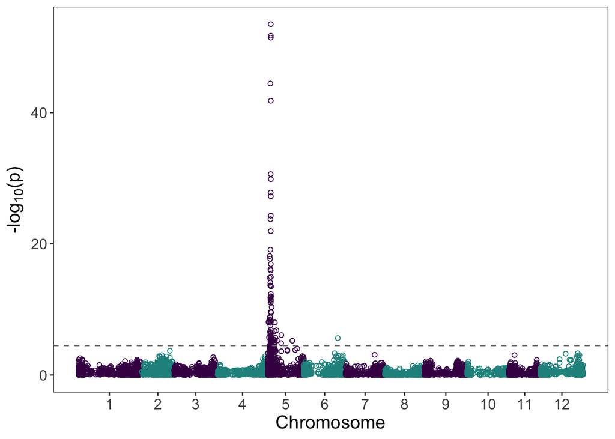

```r
manhattan.plot(data,models="additive") + guides(shape="none") + theme(strip.text = element_blank())
```

## QTL effects and R2

```r
qtl <- get.QTL(data,models="additive",bp.window=5e6)
qtl
```

```
##              Trait    Model Threshold              Marker Chrom Position Ref Alt Score     Effect
## 3873 vine.maturity additive      4.48       PotVar0078045     5  4407080   0   1 53.47 -1.2482223
## 4163 vine.maturity additive      4.48 solcap_snp_c2_49677     5 19689831   0   1  6.08  0.5674914
## 4204 vine.maturity additive      4.48 solcap_snp_c2_54566     5 35376190   0   1  5.22  0.5146530
## 4837 vine.maturity additive      4.48       PotVar0090539     6 48596917   0   1  5.62 -0.7188477
```

```r
fit.QTL(data=data,trait="vine.maturity",
        qtl=data.frame(Marker=qtl[c(1,4),"Marker"],Model="additive"),
        fixed=data.frame(Effect="env",Type="factor"))
```

```
##             Marker Chrom Position    Model         R2         pval
## 3873 PotVar0078045     5  4407080 additive 0.24042064 1.520476e-56
## 4837 PotVar0090539     6 48596917 additive 0.02479441 1.686518e-06
```

The QTL on chr05 explains 24% of the variation vs. 2.5% for the QTL on chr06.

# diaQTL

diaQTL ([Amadeu et al, 2021](https://academic.oup.com/genetics/article/219/3/iyab124/6339585?login=false)) is an R package designed for QTL and haplotype analysis of autotetraploid (and diploid) diallel populations. Phenotypes are regressed on genotype probabilities, and the regression coefficients are random effects ([Vignette](https://jendelman.github.io/diaQTL/diaQTL_Vignette.html)). The PolyOrigin software is recommended to calculate the genotype probabilities for tetraploids.

## Haplotype reconstruction

[PolyOrigin](https://github.com/chaozhi/PolyOrigin.jl) (Zheng et al. 2021)

A package for haplotype reconstruction in connected tetraploid F1 populations. Runs in [Julia](https://julialang.org/downloads/). There are vignettes available for different data types. This example uses potato data from a 3x3 diallel population.

From Julia:

```julia
using PolyOrigin
cd("/Users/mariacaraza/Downloads/MCH_QTLanalysis/data/PolyOrigin_example/")
genofile="RedDiallele_geno.csv"
pedfile="RedDiallele_ped.csv"
```

Check input files:

```julia
using CSV, DataFrames, Plots
show(CSV.read(pedfile,DataFrame)[1:8,:],eltypes=false)
show(CSV.read(genofile,DataFrame)[1:5,1:7],eltypes=false)
```

Plot cross design for the 3x3 diallel cross:

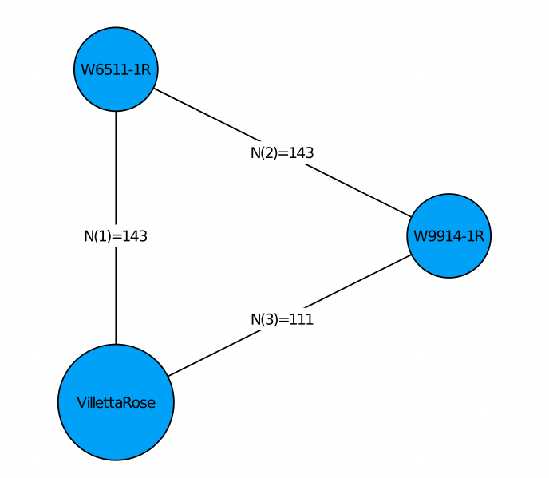

```julia
polygeno = readPolyGeno(genofile, pedfile,isphysmap=true)
PolyOrigin.plotdesign(polygeno)
```

Run PolyOrigin (takes ~8 min with subset data):

```julia
@time polyancestry = polyOrigin(genofile, pedfile;
                                isphysmap=true,
                                recomrate=1.25,
                                refinemap=true,
                                refineorder=false,
                                chrsubset=1:1,
                                snpsubset=1:5:1000,
                                isparallel=true,
                                outstem="Subset_PotatoDiallel")
```

The returned polyancestry from polyOrigin has been saved:

`outfiles = filter(x->occursin("Subset_PotatoDiallel",x), readdir())`

```
7-element Vector{String}:
 "Subset_PotatoDiallel.log"
 "Subset_PotatoDiallel_genoprob.csv"
 "Subset_PotatoDiallel_maprefined.csv"
 "Subset_PotatoDiallel_parentphased.csv"
 "Subset_PotatoDiallel_parentphased_corrected.csv"
 "Subset_PotatoDiallel_polyancestry.csv"
 "Subset_PotatoDiallel_postdoseprob.csv"
```

Visualize haplotype probabilities of a single offspring

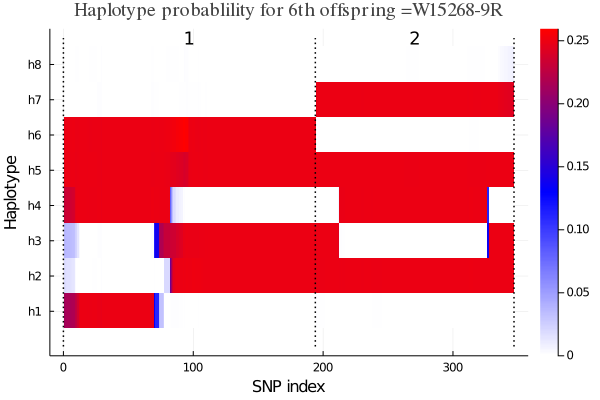

```julia
plotCondprob(polyancestry,offspring=6)
savefig("Subset_PotatoDiallel_Offspring6.png")
```

## QTL analysis using diaQTL

### Import the data

Input files needed for QTL analysis: pedigree file, genotype file, and phenotype file. Several functions are available to prepare input files from PolyOrigin, MAPpoly, RABBIT, and onemap.

To install:

```r
install.packages("devtools")
devtools::install_github("jendelman/diaQTL", build_vignettes=FALSE)
```

#### Load and convert data

Load the package and convert data from PolyOrigin:

```r
library(diaQTL)
library(ggplot2)

setwd("../data/PolyOrigin_example/FullOutput/")
ans1 <- convert_polyorigin(filename="Potato_diallel_output_polyancestry.csv", mapfile="RedDiallele_mapfile.csv")
```

The files generated are stored in the same working directory. Look for files named:

```
diaQTL_genofile.csv
diaQTL_parents.csv
diaQTL_pedfile.csv
```

**1. Pedigree file**

```r
pedcsv <- "../data/diaQTL_example/diaQTL_pedfile.csv"
ped <- read.csv(pedcsv, as.is = T, check.names = F )
head(ped)
```

```
##          id  parent1      parent2
## 1 W15268-4R W6511-1R VillettaRose
## 2 W15268-5R W6511-1R VillettaRose
## 3 W15268-6R W6511-1R VillettaRose
## 4 W15268-7R W6511-1R VillettaRose
## 5 W15268-8R W6511-1R VillettaRose
## 6 W15268-9R W6511-1R VillettaRose
```

**2. Genotype file**

```r
genocsv <- "../data/diaQTL_example/diaQTL_genofile.csv"
geno <- read.csv(genocsv, as.is = T, check.names = F )
geno[1:5,1:4]
```

```
##                marker chrom   cM     bp
## 1 solcap_snp_c2_36608     1 0.00 251132
## 2 solcap_snp_c2_36658     1 0.07 269400
## 3 solcap_snp_c1_10930     1 0.14 309342
## 4       PotVar0120130     1 0.43 353979
## 5 solcap_snp_c2_36629     1 0.66 433801
```

**3. Phenotype file**

```r
phenocsv <- "../data/diaQTL_example/VMdiallel.csv"
pheno <- read.csv( phenocsv, as.is = T, check.names = F)
head(pheno)
```

```
##           id vine.maturity
## 1 W15263-10R      7.214876
## 2 W15263-11R      2.214876
## 3 W15263-12R      5.503944
## 4 W15263-16R      5.214876
## 5 W15263-18R      2.214876
## 6 W15263-19R      8.086716
```

#### Read the data

Read data using `read_data`, this function reads the three files (it takes ~5 min).

```r
diallel_vine <- read_data(genofile = genocsv,
                          ploidy = 4,
                          pedfile = pedcsv,
                          phenofile = phenocsv,
                          dominance = 4,
                          n.core = 3)
```

```
## 394 individuals with pedigree and genotype data
## 394 individuals with pedigree, genotype and phenotype data
## Preparing genotype data...
## Preparing for polygenic effects...
```

### QTL discovery

The `scan1` function performs a linear regression for each position in the map (it takes ~3 min).

```r
scan1.vine <- scan1( data = diallel_vine,
                     trait = "vine.maturity",
                     params = list(burnIn=50,nIter=600),
                     chrom = NULL,
                     dominance = 1,
                     n.core = 3)
```

#### Detection threshold

Get the map size using `get_map` function, and the DIC threshold using `DIC_thresh`.

```r
get_map(diallel_vine)
```

```
##     chrom Morgans
## 1       1    1.43
## 2       2    0.99
## 3       3    1.61
## 4       4    1.21
## 5       5    0.94
## 6       6    0.98
## 7       7    0.93
## 8       8    0.94
## 9       9    1.14
## 10     10    1.08
## 11     11    0.87
## 12     12    1.02
## 13 total:   13.12
```

```r
alpha.05 <- DIC_thresh(genome.size=13.12,num.parents=3,
                       ploidy=4,alpha=0.05)
alpha.1 <- DIC_thresh(genome.size=13.12,num.parents=3,
                      ploidy=4,alpha=0.1)
cat(alpha.1,alpha.05)
```

```
## 17.74 20.04
```

[output not shown]

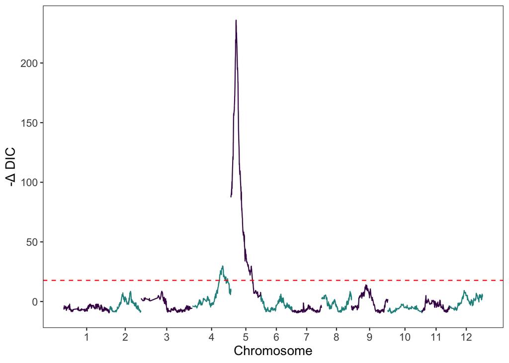

```r
ans1 <- scan1_summary(scan1.vine)

ans1$plot + geom_hline(yintercept = 17.74,linetype=2,colour="red")
```

```r
ans1$peaks
```

```
##                   marker chrom    cM       bp        LL    deltaDIC
## 494   solcap_snp_c1_5150     1 82.68 66675618 -873.2518    2.111709
## 1789 solcap_snp_c2_53033     2 66.25 38688568 -868.5986   -8.512416
## 2088  solcap_snp_c1_8970     3 64.87  5430309 -867.3345   -8.588400
## 3357       PotVar0123717     4 94.60 65866032 -857.8626  -29.836555
## 3833       PotVar0079803     5 16.37  4628704 -752.4716 -235.915786
## 4814 solcap_snp_c2_31139     6 62.85 48874844 -868.7315   -6.169131
## 5267  solcap_snp_c2_6574     7 35.90 11797542 -873.5073    0.964122
## 6289 solcap_snp_c2_46266     8 89.60 55639343 -869.2478   -8.416069
## 6582       PotVar0107319     9 44.97 11226508 -865.7746  -13.938100
## 7179 solcap_snp_c2_40826    10 48.20 45821679 -874.0473    2.152734
## 7643  solcap_snp_c2_6108    11 11.86  3886505 -869.9490   -4.975977
## 8351 solcap_snp_c2_27379    12 44.70 10256960 -867.1122   -9.237761
```

#### QTL modeling

Fitting a multiple QTL model with `fitQTL`.

```r
qtl.4 <- ans1$peaks$marker[4]
qtl.5 <- ans1$peaks$marker[5]

fit.vine <- fitQTL(data=diallel_vine,trait="vine.maturity",
               params=list(burnIn=100,nIter=3000),
               qtl=data.frame(marker=c(qtl.4,qtl.5),dominance=c(1,1)))
```

Plotting the additive haplotype effect

`fit.vine$plots$PotVar0079803$additive`

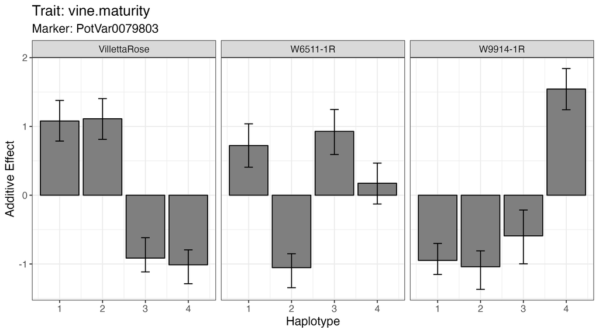

Proportion of variance for the effects

```r
fit.vine$var
```

```
##                        Mean CI.lower CI.upper
## PotVar0123717 additive 0.05     0.02     0.10
## PotVar0079803 additive 0.43     0.36     0.49
## residual               0.52     0.47     0.58
```

#### Haplotype-based Selection

Once the desirable haplotype is selected, using the function `haplo_get` we can extract the dosage of this haplotype across the population.

```r
haplos <- haplo_get( data = diallel_vine, marker = qtl.5)

which(haplos[,"W6511-1R.2"] > 1.8) #which individuals have 2 copies of "W6511-1R.2"
```

```
##  W15268-65R W15268-134R W15267-213R W15267-171R
##          37          83         229         261
```

We use the function `haplo_plot` to visualize the pattern of recombination between parental haplotypes.

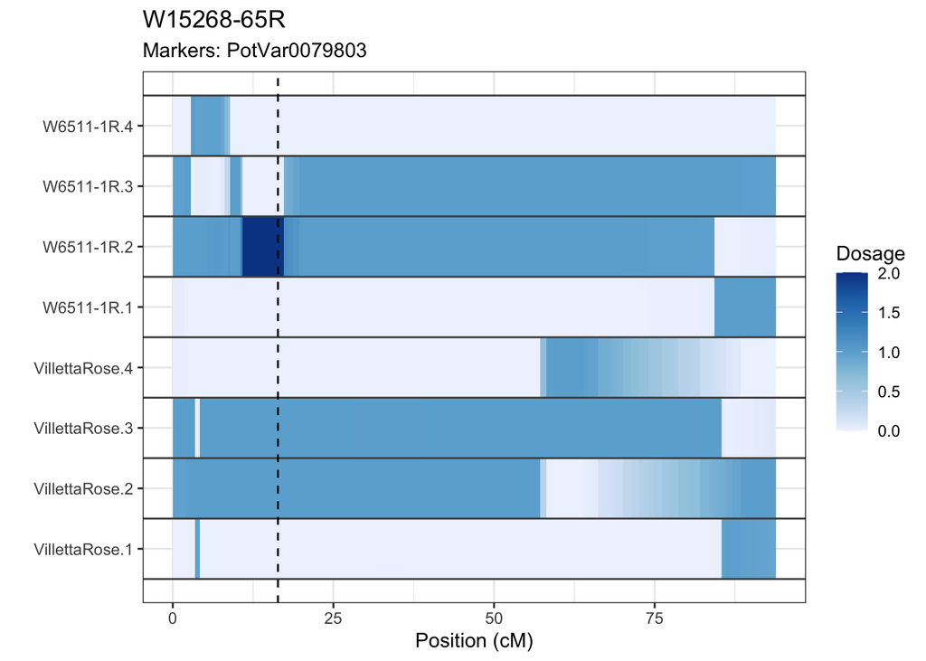

```r
haplo_plot( data = diallel_vine,
            id = "W15268-65R",
            chrom = 5,
            position = "cM",
            marker = qtl.5)
```